# Weight Lifting Exercises

*Yizhi Fang*

## Introduction

In this report, data is collected from accelerometers on the belt, forearm, arm, and dumbell of 6 participants(Velloso et al., 2013). They were asked to perform barbell lifts correctly and incorrectly in 5 different ways. The goal is to predict the manner in which they did the exercise (indicated in variable `classe`). More information and data resource: http://groupware.les.inf.puc-rio.br/har

Training data are available here: https://d396qusza40orc.cloudfront.net/predmachlearn/pml-training.csv

Testing data are available here: https://d396qusza40orc.cloudfront.net/predmachlearn/pml-testing.csv

## Data cleaning

```r
library(caret)
library(randomForest)
```

```r
library(ggplot2)
```

```r
if (!file.exists("./pml-training.csv")){
    download.file("https://d396qusza40orc.cloudfront.net/predmachlearn/pml-training.csv", destfile="./pml-training.csv", method="curl")
}
trainingRaw <- read.csv("./pml-training.csv")

if (!file.exists("./pml-testing.csv")){
    download.file("https://d396qusza40orc.cloudfront.net/predmachlearn/pml-testing.csv", destfile="./pml-testing.csv", method="curl")
}
testingRaw <- read.csv("./pml-testing.csv")
```

There’re 19622 observations and 160 variables in the training data and some of them have missing values because there’re only 406 complete cases.

First, we remove those variables that have missing values and then some that don’t contribute to the model.

```r
temp <- trainingRaw[, colSums(is.na(trainingRaw)) == 0]
training <- temp[, !grepl("^X|timestamp|window$", names(temp))]
dim(training)
```

```
## [1] 19622    87
```

```r
temp <- testingRaw[, colSums(is.na(testingRaw)) == 0]
testing <- temp[, !grepl("^X|timestamp|window$", names(temp))]
dim(testing)
```

```
## [1] 20 54
```

It looks like that testing data has more variables with missing values. Therefore, we here only remain the match variables in both data sets for consistancy. However, testing data doesn’t have `classe` variable (the outcome of the predictions) because of its 0 length.

```r
classe <- training$classe
both <- intersect(names(training), names(testing))

trainingFinal <- training[, both]
trainingFinal$classe <- classe

testingFinal <- testing[, both]
```

## Data training

In this report, we decide to use **Random Forest** algorithm that combines resampling of both data and variables. First, we need to split the training data into `trainingDP` and `testingDP`.

```r
set.seed(33893)
inTrain <- createDataPartition(trainingFinal$classe, p=0.75, list=F)
trainingDP <- trainingFinal[inTrain, ]
testingDP <- trainingFinal[-inTrain, ]
```

However, the disadvantage of this method is that it can easily overfit. Therefore, we train the data with **Random Forest** with 5-fold cross-validation control.

```r
modelFit <- train(classe ~ ., data=trainingDP, trControl=trainControl(method="cv", 5), method="rf", ntree=200)

modelFit
```

```
## Random Forest
##
## 14718 samples
##    53 predictor
##     5 classes: 'A', 'B', 'C', 'D', 'E'
##
## No pre-processing
## Resampling: Cross-Validated (5 fold)
## Summary of sample sizes: 11775, 11775, 11773, 11773, 11776
## Resampling results across tuning parameters:
##
##   mtry  Accuracy   Kappa      Accuracy SD  Kappa SD
##    2    0.9902843  0.9877086  0.002194800  0.002776899
##   29    0.9910319  0.9886545  0.003876452  0.004905445
##   57    0.9830147  0.9785093  0.004585659  0.005806655
##
## Accuracy was used to select the optimal model using  the largest value.
## The final value used for the model was mtry = 29.
```

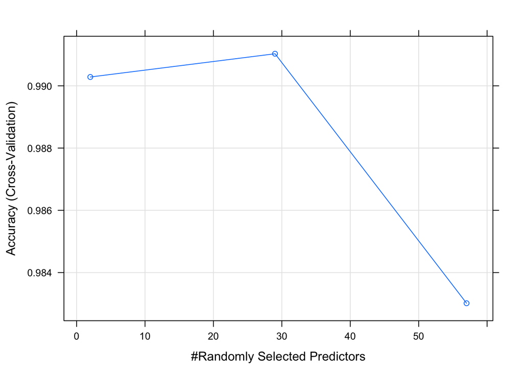

```r
plot(modelFit)
```

Now we can estimate the performance of the model via the `testingDP`.

```r
predictions <- predict(modelFit, testingDP)
confusionMatrix(predictions, testingDP$classe)
```

```
## Confusion Matrix and Statistics
##
##           Reference
## Prediction    A    B    C    D    E
##          A 1394    5    0    0    0
##          B    0  939    3    1    1
##          C    0    5  851    7    1
##          D    0    0    1  795    1
##          E    1    0    0    1  898
##
## Overall Statistics
##
##                Accuracy : 0.9945
##                  95% CI : (0.992, 0.9964)
##     No Information Rate : 0.2845
##     P-Value [Acc > NIR] : < 2.2e-16
##
##                   Kappa : 0.993
##  Mcnemar's Test P-Value : NA
##
## Statistics by Class:
##
##                      Class: A Class: B Class: C Class: D Class: E
## Sensitivity            0.9993   0.9895   0.9953   0.9888   0.9967
## Specificity            0.9986   0.9987   0.9968   0.9995   0.9995
## Pos Pred Value         0.9964   0.9947   0.9850   0.9975   0.9978
## Neg Pred Value         0.9997   0.9975   0.9990   0.9978   0.9993
## Prevalence             0.2845   0.1935   0.1743   0.1639   0.1837
## Detection Rate         0.2843   0.1915   0.1735   0.1621   0.1831
## Detection Prevalence   0.2853   0.1925   0.1762   0.1625   0.1835
## Balanced Accuracy      0.9989   0.9941   0.9961   0.9942   0.9981
```

From the confusion matrix analysis, the overall accuracy is 99.45% and the out-of-sample error is 0.55%, which tells us the chosen **Random Forest** algorithm predicts our `testingDP` well.

## Prediction

Finally, we could estimate the testing data with the chosen model.

```r
result <- predict(modelFit, testingFinal)
data.frame(user_name=testingFinal$user_name, preformance=result)
```

```
##    user_name preformance
## 1      pedro           B
## 2     jeremy           A
## 3     jeremy           B
## 4     adelmo           A
## 5     eurico           A
## 6     jeremy           E
## 7     jeremy           D
## 8     jeremy           B
## 9   carlitos           A
## 10   charles           A
## 11  carlitos           B
## 12    jeremy           C
## 13    eurico           B
## 14    jeremy           A
## 15    jeremy           E
## 16    eurico           E
## 17     pedro           A
## 18  carlitos           B
## 19     pedro           B
## 20    eurico           B
```